# R Gym Trainer

Tanveer Ansari

Saturday, May 23, 2015

### Load and Clean Data

```r
if(!file.exists("train.rds")){
  trainURL<-getURL("https://d396qusza40orc.cloudfront.net/predmachlearn/pml-training.csv")
  trainAll<-read.csv(text=trainURL)
  saveRDS(trainAll,"train.rds")
  } else {
    trainAll<-readRDS("train.rds") ##Training dataset
    }

if(!file.exists("test.rds")){
  testURL<-getURL("https://d396qusza40orc.cloudfront.net/predmachlearn/pml-testing.csv")
  testingFinal<-read.csv(text=testURL)
  saveRDS(testingFinal,"test.rds")
  } else {
    testingFinal<-readRDS("test.rds")  ## Testing dataset
    }
```

**Remove irrelevant columns**  
1. Remove the column X - this is the order in which the data is presented  
2. Remove the user_name and num_window columns - I do not believe they are relevants as factors  
3. Remove all timestamp columns - this analysis did not treat this data as time series data

```r
tidyTrain<-trainAll
tidyTrain$X<-NULL # remove sequence number from data
tidyTrain$user_name<-NULL
tidyTrain$num_window<-NULL
# remove timestamp columns from dataset
tidyTrain<-tidyTrain[,-grep("time",names(tidyTrain))]
```

**Remove fields with minimal variance** - most likely these are not good predictors

```r
nzv<-nearZeroVar(tidyTrain)
removedCols<-names(tidyTrain)[nzv] # Print names of removed columns
tidyTrain<-(tidyTrain[,-nzv])
head(removedCols)
```

```
## [1] "new_window"           "kurtosis_roll_belt"   "kurtosis_picth_belt"
## [4] "kurtosis_yaw_belt"    "skewness_roll_belt"   "skewness_roll_belt.1"
```

**Remove fields that are mostly NAs.**  
I chose 97% NAs as the threshold for removal

```r
nullMoreThan97<-apply(tidyTrain,2,function(x){as.logical(sum(is.na(x))/length(x) > 0.975)})
#which(nullMoreThan97)
tidyTrain<-tidyTrain[,-which(nullMoreThan97)]
```

### Split data for cross validation

The training data was split up into a training and a test set in a 75/25 split

```r
set.seed(34455) # Set seed so results are reproducible
trainIndex <- createDataPartition(y=tidyTrain$classe, p=0.75, list=FALSE)
training<- tidyTrain[trainIndex,]
testing<- tidyTrain[-trainIndex,]
```

### Model Fitting

#### Decision Tree Models

I first fit a decision tree model to the training subset and evaluated its accuracy

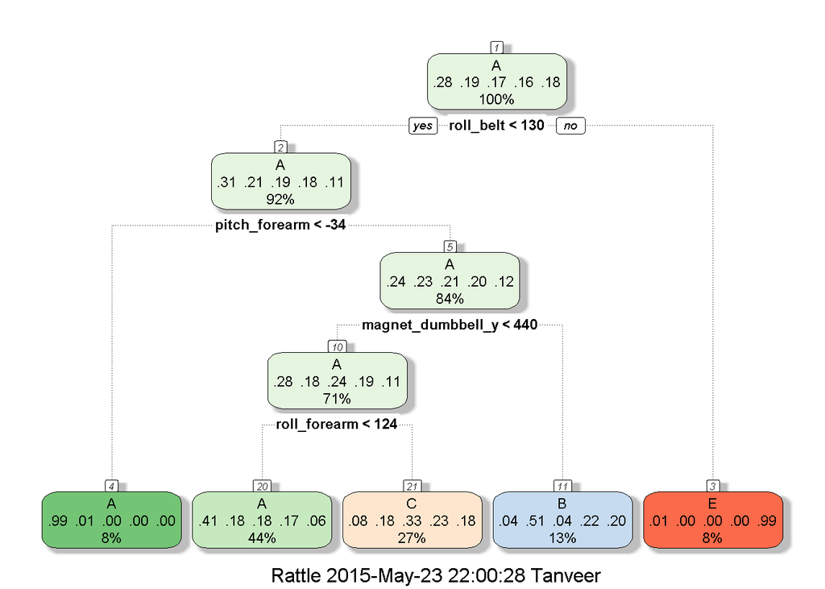

```r
rpMdl<-train(classe~.,method="rpart",data=training) # Train Model
testing$predicted <- predict(rpMdl, newdata = testing) # Predict on testing subset
fancyRpartPlot(rpMdl$finalModel)
```

This looks promising, lets check accuracy

```r
table(testing$predicted,testing$classe)
```

```
##
##        A    B    C    D    E
##   A 1283  416  406  356  132
##   B   12  327   34  151  116
##   C   95  206  415  297  256
##   D    0    0    0    0    0
##   E    5    0    0    0  397
```

```r
confusionMatrix(testing$predicted,testing$classe) # Evaluate prediction accuracy on test set
```

```
## Confusion Matrix and Statistics
##
##           Reference
## Prediction    A    B    C    D    E
##          A 1283  416  406  356  132
##          B   12  327   34  151  116
##          C   95  206  415  297  256
##          D    0    0    0    0    0
##          E    5    0    0    0  397
##
## Overall Statistics
##
##                Accuracy : 0.4939
##                  95% CI : (0.4798, 0.508)
##     No Information Rate : 0.2845
##     P-Value [Acc > NIR] : < 2.2e-16
##
##                   Kappa : 0.3377
##  Mcnemar's Test P-Value : NA
##
## Statistics by Class:
##
##                      Class: A Class: B Class: C Class: D Class: E
## Sensitivity            0.9197  0.34457  0.48538   0.0000  0.44062
## Specificity            0.6267  0.92086  0.78908   1.0000  0.99875
## Pos Pred Value         0.4948  0.51094  0.32703      NaN  0.98756
## Neg Pred Value         0.9515  0.85413  0.87895   0.8361  0.88805
## Prevalence             0.2845  0.19352  0.17435   0.1639  0.18373
## Detection Rate         0.2616  0.06668  0.08462   0.0000  0.08095
## Detection Prevalence   0.5288  0.13051  0.25877   0.0000  0.08197
## Balanced Accuracy      0.7732  0.63272  0.63723   0.5000  0.71969
```

The accuracy was ~49% for my run - terrible.  
Next lets fit another decision tree , this time using rpart2 instead of rpart

```r
rpMdl<-train(classe~.,method="rpart2",data=training) # Train Model
testing$predicted <- predict(rpMdl, newdata = testing) # Predict on testing subset
confusionMatrix(testing$predicted,testing$classe)
```

```
## Confusion Matrix and Statistics
##
##           Reference
## Prediction    A    B    C    D    E
##          A 1283  416  406  356  132
##          B   12  294   33    6   26
##          C   69   85  351  115  109
##          D   26  154   65  327  167
##          E    5    0    0    0  467
##
## Overall Statistics
##
##                Accuracy : 0.5551
##                  95% CI : (0.541, 0.569)
##     No Information Rate : 0.2845
##     P-Value [Acc > NIR] : < 2.2e-16
##
##                   Kappa : 0.4196
##  Mcnemar's Test P-Value : < 2.2e-16
##
## Statistics by Class:
##
##                      Class: A Class: B Class: C Class: D Class: E
## Sensitivity            0.9197  0.30980  0.41053  0.40672  0.51831
## Specificity            0.6267  0.98053  0.90664  0.89951  0.99875
## Pos Pred Value         0.4948  0.79245  0.48148  0.44249  0.98941
## Neg Pred Value         0.9515  0.85550  0.87928  0.88547  0.90208
## Prevalence             0.2845  0.19352  0.17435  0.16395  0.18373
## Detection Rate         0.2616  0.05995  0.07157  0.06668  0.09523
## Detection Prevalence   0.5288  0.07565  0.14865  0.15069  0.09625
## Balanced Accuracy      0.7732  0.64517  0.65858  0.65311  0.75853
```

This model showed an improved accuracy of ~55% - better but still terrible

#### Random Forest Model

Next fit a random forest model. This took several hours to run so I am using the saved model for this presentation.

```r
if(file.exists("RandomForestModelFit")) {
  rfMdl<-readRDS("RandomForestModelFit")
  } else {
    rfMdl<-train(classe~.,method="rf",data=training) # Train Model
    }

testing$predicted<-predict(rfMdl, newdata = testing)# Predict on testing subset
table(testing$predicted,testing$classe) # Evaluate prediction accuracy on test set
```

```
##
##        A    B    C    D    E
##   A 1395    4    0    0    0
##   B    0  944    0    0    0
##   C    0    1  854    5    0
##   D    0    0    1  798    0
##   E    0    0    0    1  901
```

```r
confusionMatrix(testing$predicted,testing$classe)
```

```
## Confusion Matrix and Statistics
##
##           Reference
## Prediction    A    B    C    D    E
##          A 1395    4    0    0    0
##          B    0  944    0    0    0
##          C    0    1  854    5    0
##          D    0    0    1  798    0
##          E    0    0    0    1  901
##
## Overall Statistics
##
##                Accuracy : 0.9976
##                  95% CI : (0.9957, 0.9987)
##     No Information Rate : 0.2845
##     P-Value [Acc > NIR] : < 2.2e-16
##
##                   Kappa : 0.9969
##  Mcnemar's Test P-Value : NA
##
## Statistics by Class:
##
##                      Class: A Class: B Class: C Class: D Class: E
## Sensitivity            1.0000   0.9947   0.9988   0.9925   1.0000
## Specificity            0.9989   1.0000   0.9985   0.9998   0.9998
## Pos Pred Value         0.9971   1.0000   0.9930   0.9987   0.9989
## Neg Pred Value         1.0000   0.9987   0.9998   0.9985   1.0000
## Prevalence             0.2845   0.1935   0.1743   0.1639   0.1837
## Detection Rate         0.2845   0.1925   0.1741   0.1627   0.1837
## Detection Prevalence   0.2853   0.1925   0.1754   0.1629   0.1839
## Balanced Accuracy      0.9994   0.9974   0.9987   0.9961   0.9999
```

The random forest model showed an accuracy of ~ 99.76% with a confidence interval  
of (99.57%, 99.87%) at 95% Confidence

### Out of Sample Error

Out of sample error in the testing section was (1-0.9976) = 0.0024 or 0.24% for this random forest model. The confidence interval for out-of-sample error rate was (0.13% , 0.43% )

At this out-of-sample error rate, when run on the final testing set of size 20, I expect the number of  
inaccurate results to be 0.0024*20 = 0.05. As a confidence interval the number of errors is predicted to be between 0.026 and 0.086 , out of 20 .  
In other words ZERO wrong predictions are expected

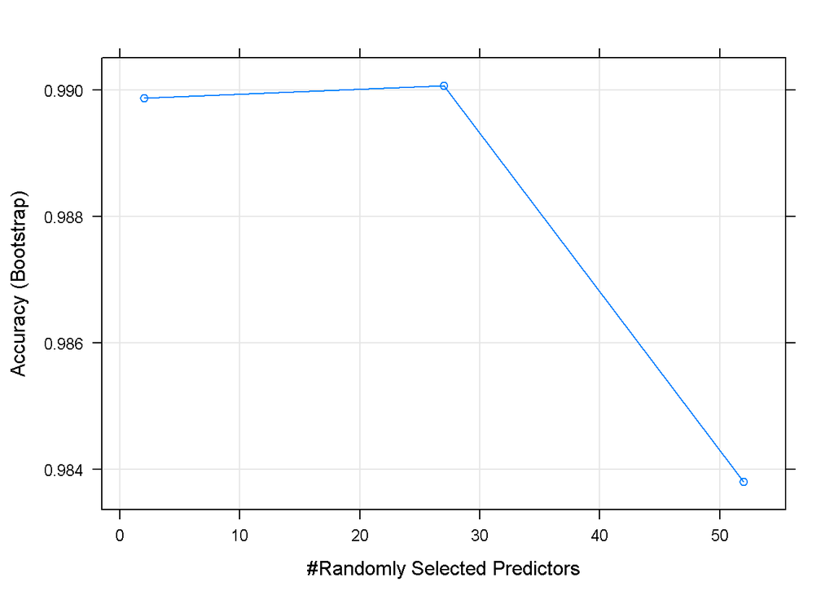

```r
plot(rfMdl, log="y")
```

```r
#varImpPlot(rfMdl)
```

### FINAL MODEL FOR PREDICTION

```r
if(file.exists("RandomForest")) {
  rfMdlFinal<-readRDS("RandomForest")
} else {
  rfMdlFinal <-train(classe~., method="rf",data=tidyTrain)
}

# Predict testing set with Random Forest Model
testingFinal$classe<-predict(rfMdlFinal,newdata=testingFinal)
```